# Surprisal analyses with complexity data

Molly Lewis

2016-02-16

#### Reviewer 1 comment:

“*First, if this paper were written before the Piantadosi 2011 paper and the Mahowald 2013 papers, I could understand why the authors would feel that by controlling for frequency in experiment 9, they could get away from the Zipfian assumption that the main predictor of word length is frequency. By now the common assumption (e.g. Seyfarth 2014; Cognition) is that predictability, rather than frequency, should be the main determiner of length. For the first two series of experiments the authors may have felt that they could evade that issue by constructing novel objects, or objects for which no prior predictability of frequency accounts would apply, but that’s a very narrow view of predictability-based accounts. For instance, in the artificial object experiment series, if number of parts predicts complexity, it is not far-fetched to assume that subjects do have some predictability assessment for the novel objects, based on a naïve P(object) = [P(parts)], which would make objects with more parts less predictable, everything else being equal (and the authors seem to be aware of that on page 5, yet maintain the argument for complexity). That is, to rule out a predictability-based explanation, the authors need to contrast their findings with a model that can assign probabilities to first-seen items. If that’s what the authors mean by “complex”, then it should be spelled out. This is not only an issue for the artificial objects. For instance, body part names seem not to correspond to how difficult it is to understand their action, but rather to how likely we are to see them: ears, eyes and tongue are arguably more complex than intestine, muscle and cartilage. For existing words in Experiment 9 the authors should control for mean predictability rather than frequency (preferably for both), and then use whatever residual effect there is in Experiment 10, not bare complexity. Otherwise they do not rule out the possibility that frequency and predictability account for the correlation, at least in the lower pearson r languages. Without clearer controls for predictability and frequency, the experiments in this paper only show that subjects expect language to match their experience in matching longer words with less predictable and less frequent items, which is still interesting, but perhaps shouldn’t take 10 experiments to prove.*”

To address this, here we use the 2-gram surprisal measure calculated from the British National Corpus (BNC), and reported in the Piantadosi et al. (2011) paper. I’m not using the google books measure because I keep running in to an error when I try to process the bigrams.

Read in BNC data and complexity norms.

```r
bnc.2gram = read.table('../data/corpus/English-KNN-H-2.txt', header = T) %>%
  mutate(log.bnc.frequency = log(context.count)) %>%
  top_n(25000, abs(log.bnc.frequency)) # following Piantadosi, resttrict to most frequent words

lf.data = read.csv("../data/corpus/english_complexity_norms.csv") %>%
  group_by(word) %>%
  select(-X, -workerid, -trial) %>%
  summarise_each(funs(mean)) %>%
  left_join(bnc.2gram, by="word")
```

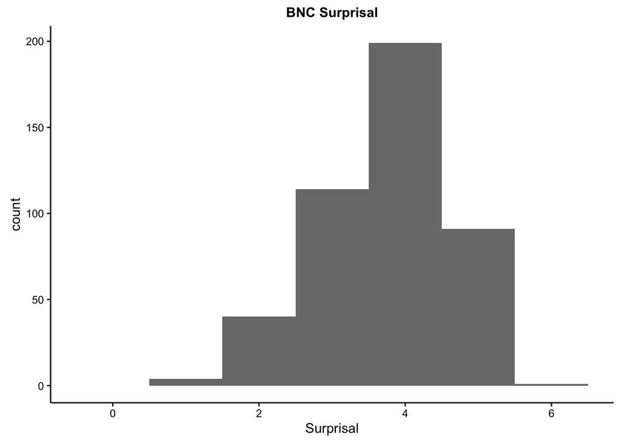

```r
ggplot(lf.data, aes(x=surprisal)) +
    geom_histogram(fill = "black", alpha = .6 , binwidth = 1,  origin = -0.5) +
  xlab("Surprisal") +
  ggtitle('BNC Surprisal') +
  themeML
```

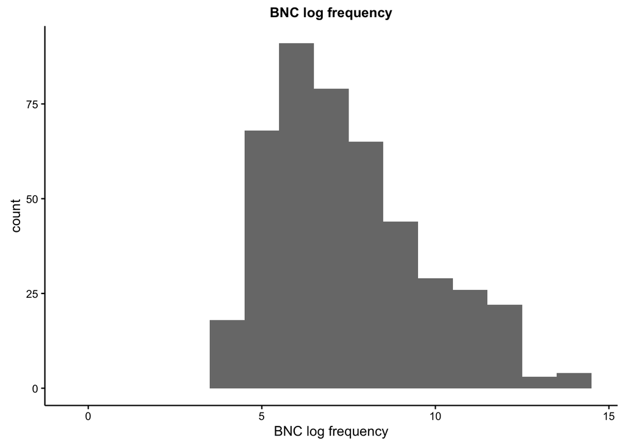

```r
ggplot(lf.data, aes(x=log.bnc.frequency)) +
    geom_histogram(fill = "black", alpha = .6 , binwidth = 1,  origin = -0.5) +
  xlab("BNC log frequency") +
  ggtitle('BNC log frequency') +
  themeML
```

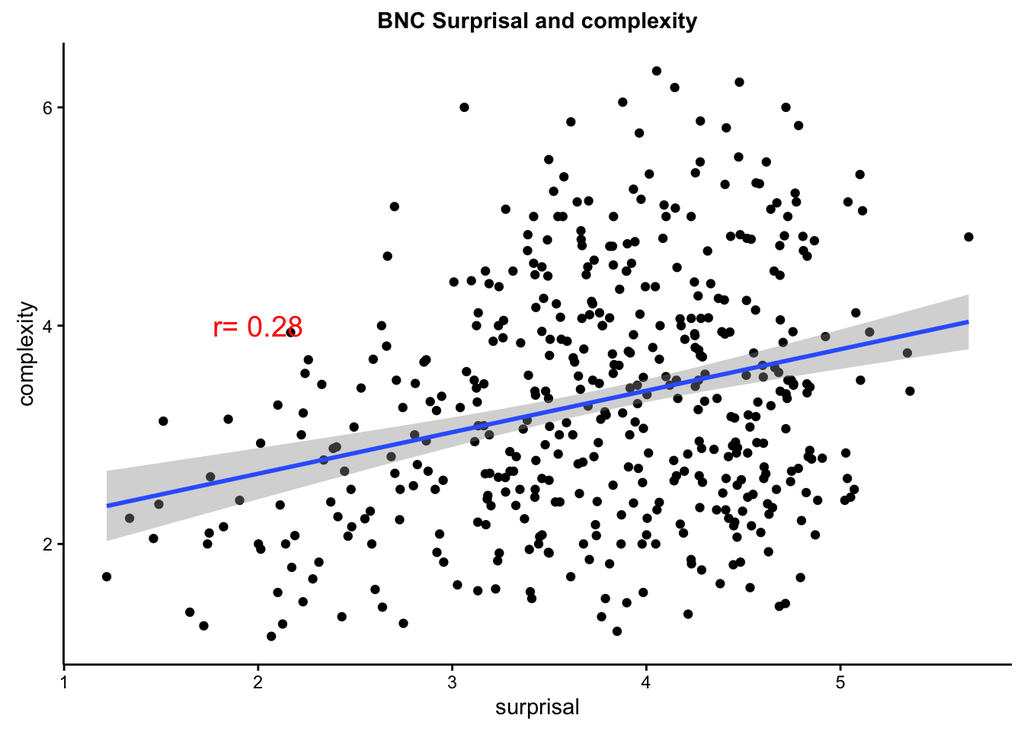

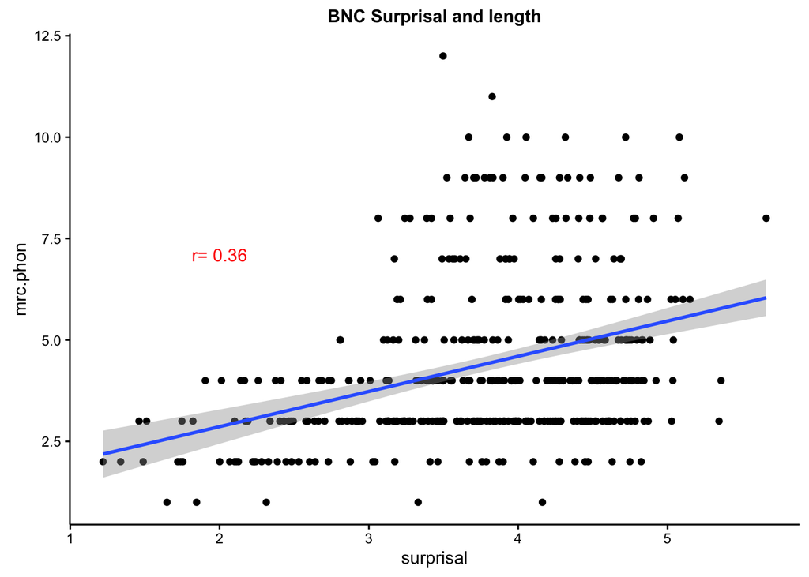

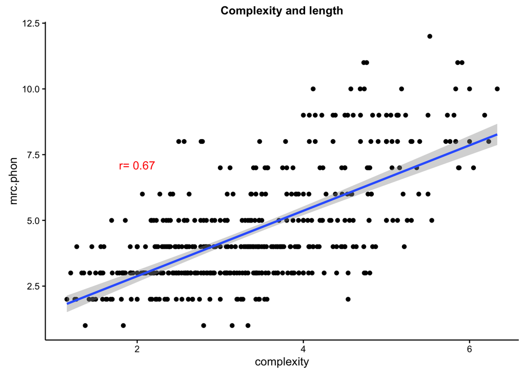

Do Piantadosi analysis complexity words and all words (UNIGRAM surprisals).

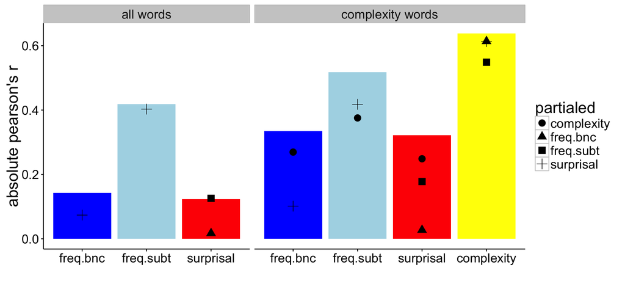

Do Piantadosi analysis complexity words and all words (BIGRAM surprisals).

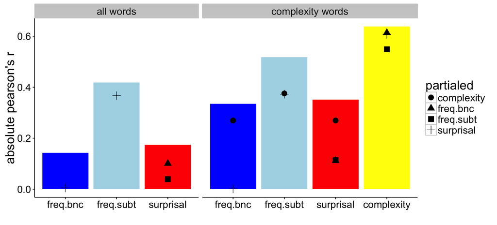

Do Piantadosi analysis complexity words and all words (TRIGRAM surprisals).

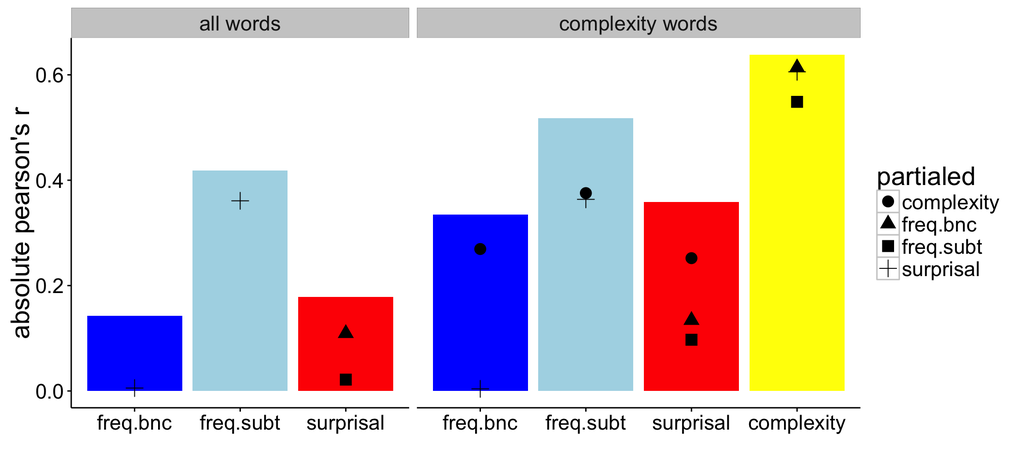

# stats for piantadosi analysis

```r
paired.r(abs(cor(bnc.2gram$len, bnc.2gram$log.bnc.frequency, method = "spearman")),
         cor(bnc.2gram$len, bnc.2gram$surprisal, method = "spearman"),n=length(bnc.2gram$len))
```

```
## Call: paired.r(xy = abs(cor(bnc.2gram$len, bnc.2gram$log.bnc.frequency,
##     method = "spearman")), xz = cor(bnc.2gram$len, bnc.2gram$surprisal,
##     method = "spearman"), n = length(bnc.2gram$len))
## [1] "test of difference between two independent correlations"
## z = 3.6  With probability =  0
```

```r
paired.r(abs(cor(bnc.3gram$len, bnc.3gram$log.bnc.frequency, method = "spearman")),
         cor(bnc.3gram$len, bnc.3gram$surprisal, method = "spearman"),n=length(bnc.3gram$len))
```

```
## Call: paired.r(xy = abs(cor(bnc.3gram$len, bnc.3gram$log.bnc.frequency,
##     method = "spearman")), xz = cor(bnc.3gram$len, bnc.3gram$surprisal,
##     method = "spearman"), n = length(bnc.3gram$len))
## [1] "test of difference between two independent correlations"
## z = 4.19  With probability =  0
```

# stats for surpisal and complexity analysis

```r
pcor.test(bnc.2gram$len, bnc.2gram$log.bnc.frequency,bnc.2gram$surprisal,method = "spearman")
```

```
##       estimate   p.value  statistic     n gn   Method            Use
## 1 -0.005151654 0.4136878 -0.8174211 25179  1 Spearman Var-Cov matrix
```

```r
tidy(lm(mrc.phon ~ complexity + surprisal + log.bnc.frequency, lf.data))
```

```
##                term    estimate  std.error  statistic      p.value
## 1       (Intercept) -0.02933587 1.63366388 -0.0179571 9.856816e-01
## 2        complexity  1.07923234 0.06705291 16.0952349 8.640533e-46
## 3         surprisal  0.32585515 0.24551279  1.3272431 1.851459e-01
## 4 log.bnc.frequency -0.04332642 0.10223195 -0.4238050 6.719239e-01
```

Now, let’s look cross-linguistically.

Read in xling data and merge with English complexity norms

Get correlations for length and complexity with for all 499 words with bootstrapped CIs

Partial correlations (with frequency and surprisal)

Get correlation for monomorphemic and open class subsets

prep for plotting